# User_analysis_1020

qingye

2017年10月20日

# 本报告对10月8日用户至10月19日节后这两周的行为进行了分析

#### 包括反映用户数目的UV,反映用户活跃度的：人均PV,用户活跃时长，以及反映用户黏度的次日留存

#### 本次报告初步用R语言进行自动化生成报告的框架搭建，今后将在此基础上不断改进优化，下次报告将加入转化方面的分析，加入对于路径方面的分析，引进异常值提醒和分析

## 近两周的日活跃度(UV)

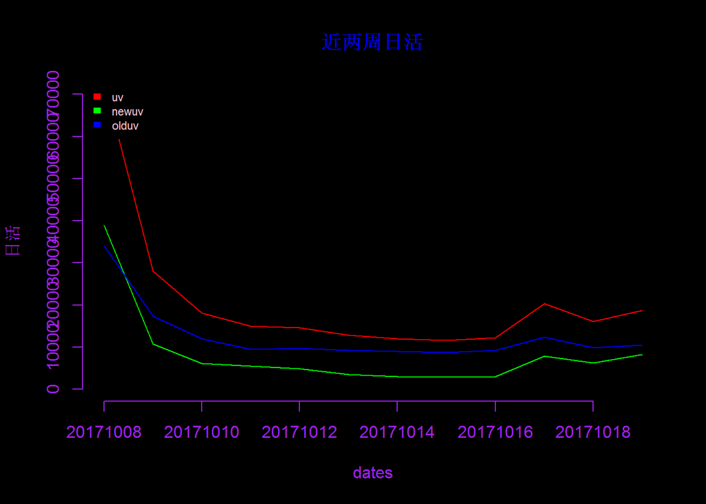

不出意料的是节日过后，uv马上冷却下来

不过从10月16日开始uv有回暖趋势，并在17日有个小高峰

访问人数上，还是老用户多一些，新老用户的趋势并无大的不同

## 近两周人均PV

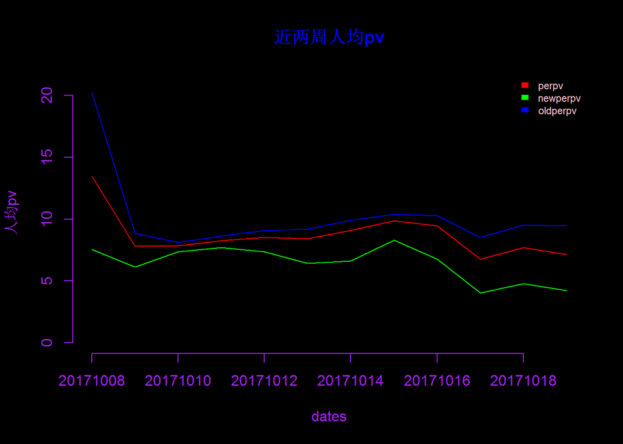

老用户比新用户在这个指标上要更显著更活跃一些

## 用户活跃时长

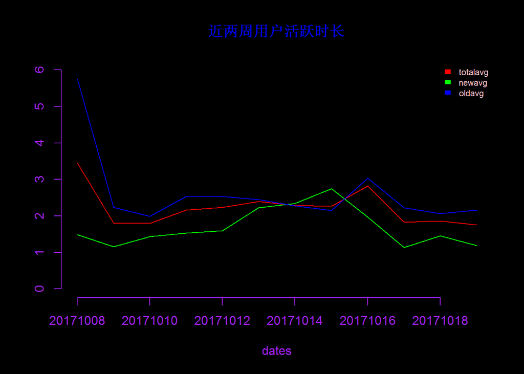

在平均活跃时长方面，新老用户的峰值有一天的滞后，新用户峰值出现在15日，老用户16日

老用户整体比新用户平均时长更长，但是在15号当天，新用户达到峰值且超过了老用户

## 次日留存

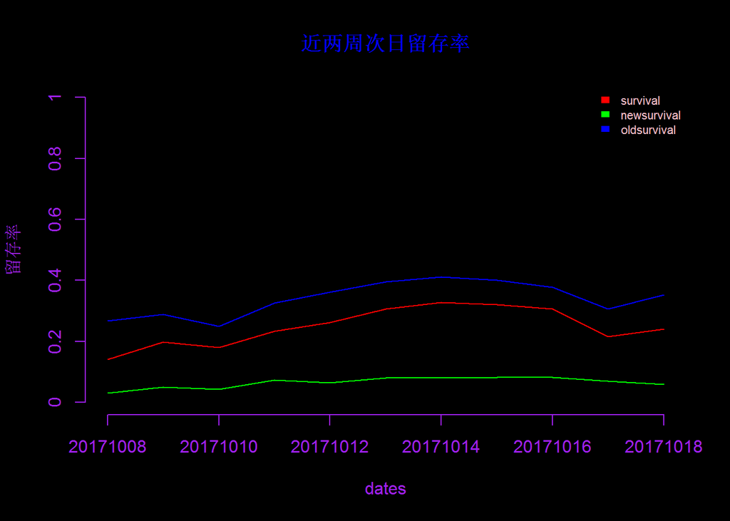

留存率节后缓慢上升，但是在17日有个比较明显的下降，可能需要调查下原因

## 新用户不同机型分布

| model | 2017-10-08 | 2017-10-09 | 2017-10-10 | 2017-10-11 | 2017-10-12 | 2017-10-13 | 2017-10-14 | 2017-10-15 | 2017-10-16 | 2017-10-17 | 2017-10-18 | 2017-10-19 | sum |
| --- | --- | --- | --- | --- | --- | --- | --- | --- | --- | --- | --- | --- | --- |
| iPhone 5c | 2570 | 3 | NA | NA | NA | 1 | 1 | NA | 1 | NA | NA | NA | 2576 |
| iPhone 5s | 2201 | 18 | 3 | 4 | 5 | 6 | 6 | 10 | 8 | 2 | 10 | 5 | 2278 |
| iPhone 5 | 2177 | 6 | 1 | NA | NA | 3 | NA | 1 | 1 | NA | 1 | 3 | 2193 |
| iPhone 6 | 1370 | 40 | 21 | 26 | 28 | 32 | 27 | 30 | 18 | 31 | 31 | 24 | 1678 |
| iPhone 6 Plus | 1281 | 33 | 17 | 17 | 20 | 18 | 31 | 26 | 17 | 21 | 20 | 15 | 1516 |
| vivo X9 | 616 | 84 | 30 | 29 | 20 | 20 | 16 | 16 | 10 | 168 | 88 | 144 | 1241 |
| vivo X7 | 520 | 103 | 61 | 40 | 43 | 20 | 19 | 11 | 13 | 95 | 88 | 92 | 1105 |
| iPhone 4S | 1067 | 1 | 2 | 2 | 3 | 1 | 1 | NA | NA | 1 | NA | NA | 1078 |
| Redmi Note 3 | 224 | 151 | 74 | 70 | 38 | 33 | 14 | 16 | 30 | 65 | 95 | 100 | 910 |
| iPhone 7 Plus | 275 | 48 | 42 | 28 | 35 | 45 | 55 | 39 | 30 | 31 | 24 | 33 | 685 |
| Redmi Note 2 | 166 | 122 | 63 | 46 | 39 | 10 | 12 | 7 | 17 | 46 | 57 | 62 | 647 |
| vivo Y66 | 301 | 57 | 24 | 13 | 12 | 17 | 12 | 9 | 9 | 78 | 46 | 67 | 645 |
| OPPO A33 | 217 | 95 | 66 | 46 | 44 | 15 | 8 | 11 | 14 | 32 | 19 | 32 | 599 |
| MHA-AL00 | 131 | 62 | 35 | 29 | 48 | 32 | 40 | 38 | 32 | 47 | 44 | 59 | 597 |
| Redmi Note 4X | 94 | 98 | 44 | 26 | 23 | 24 | 20 | 12 | 16 | 74 | 86 | 67 | 584 |
| MI 5 | 113 | 91 | 40 | 43 | 36 | 23 | 20 | 29 | 27 | 41 | 42 | 62 | 567 |
| MI 4LTE | 156 | 94 | 49 | 46 | 23 | 16 | 12 | 7 | 7 | 51 | 55 | 47 | 563 |
| HM NOTE 1LTE | 104 | 121 | 56 | 37 | 34 | 11 | 8 | 10 | 18 | 39 | 42 | 71 | 551 |
| iPhone 6s | 273 | 31 | 18 | 22 | 30 | 30 | 14 | 33 | 28 | 21 | 18 | 28 | 546 |
| OPPO A37m | 132 | 92 | 35 | 40 | 41 | 19 | 19 | 12 | 22 | 35 | 39 | 42 | 528 |
| HUAWEI NXT-AL10 | 107 | 74 | 50 | 38 | 48 | 23 | 25 | 21 | 19 | 40 | 38 | 37 | 520 |
| MI 6 | 82 | 66 | 50 | 39 | 36 | 36 | 28 | 38 | 34 | 33 | 38 | 31 | 511 |
| OPPO R9s | 130 | 57 | 16 | 20 | 32 | 22 | 32 | 28 | 24 | 36 | 53 | 56 | 506 |
| BLN-AL10 | 107 | 97 | 61 | 35 | 26 | 10 | 11 | 8 | 12 | 41 | 38 | 58 | 504 |
| vivo X9Plus | 271 | 22 | 12 | 11 | 9 | 6 | 4 | 6 | 6 | 70 | 30 | 43 | 490 |
| vivo Y51A | 161 | 95 | 47 | 27 | 33 | 8 | 5 | 9 | 7 | 37 | 23 | 34 | 486 |
| iPhone | NA | NA | NA | NA | NA | NA | NA | NA | NA | 19 | 232 | 234 | 485 |
| HM 2A | 143 | 80 | 41 | 29 | 25 | 14 | 6 | 8 | 11 | 35 | 44 | 47 | 483 |
| vivo X7Plus | 248 | 29 | 17 | 9 | 7 | 3 | 5 | 9 | 6 | 63 | 32 | 55 | 483 |
| iPhone 6s Plus | 228 | 23 | 25 | 20 | 20 | 18 | 27 | 26 | 19 | 26 | 22 | 19 | 473 |

[output cut: 70 more lines]

iphone 在国庆最后一天有很多新用户，但是节日过后大幅减少，反倒不如一些普通的android,尤其是iphone 5 系列,

iphone 6, iphone 6 plus, 仍然有一定的增加，除了节日，排名前50的手机差别不大，

当然要深入洞察需要对不同机型用户的行为进行分析

## 新用户不同城市分布

| city | 2017-10-08 | 2017-10-09 | 2017-10-10 | 2017-10-11 | 2017-10-12 | 2017-10-13 | 2017-10-14 | 2017-10-15 | 2017-10-16 | 2017-10-17 | 2017-10-18 | 2017-10-19 | sum |
| --- | --- | --- | --- | --- | --- | --- | --- | --- | --- | --- | --- | --- | --- |
| 上海 | 2686 | 216 | 169 | 379 | 350 | 390 | 311 | 270 | 308 | 248 | 662 | 782 | 6771 |
| 苏州 | 3809 | 78 | 47 | 153 | 120 | 127 | 72 | 67 | 82 | 85 | 141 | 84 | 4865 |
| 北京 | 1123 | 231 | 167 | 500 | 403 | 422 | 287 | 228 | 310 | 312 | 359 | 299 | 4641 |
| 南京 | 805 | 196 | 152 | 238 | 196 | 189 | 158 | 165 | 185 | 228 | 195 | 244 | 2951 |
| 沈阳 | 1337 | 201 | 115 | 88 | 66 | 10 | 11 | 14 | 22 | 72 | 69 | 78 | 2083 |
| 合肥 | 434 | 152 | 131 | 171 | 141 | 84 | 54 | 50 | 69 | 96 | 87 | 117 | 1586 |
| 广州 | 374 | 139 | 84 | 102 | 21 | 24 | 25 | 24 | 27 | 157 | 112 | 145 | 1234 |
| 成都 | 303 | 149 | 58 | 27 | 37 | 32 | 29 | 36 | 41 | 151 | 103 | 142 | 1108 |
| 重庆 | 289 | 122 | 51 | 26 | 33 | 33 | 34 | 40 | 39 | 142 | 103 | 130 | 1042 |
| 哈尔滨 | 376 | 180 | 116 | 66 | 53 | 19 | 14 | 14 | 14 | 58 | 45 | 62 | 1017 |
| 无锡 | 184 | 64 | 35 | 121 | 128 | 93 | 61 | 67 | 72 | 44 | 50 | 28 | 947 |
| 连云港 | 247 | 214 | 139 | 112 | 90 | 3 | 2 | 3 | 4 | 20 | 10 | 16 | 860 |
| 金华 | 283 | 206 | 114 | 95 | 83 | 2 | 4 | 4 | 5 | 15 | 11 | 8 | 830 |
| 扬州 | 163 | 111 | 97 | 119 | 86 | 50 | 25 | 28 | 43 | 41 | 33 | 18 | 814 |
| 郑州 | 240 | 105 | 43 | 22 | 26 | 19 | 22 | 23 | 18 | 79 | 69 | 95 | 761 |
| 天津 | 192 | 113 | 30 | 23 | 11 | 17 | 20 | 28 | 22 | 99 | 65 | 106 | 726 |
| 济南 | 183 | 99 | 37 | 25 | 32 | 22 | 19 | 26 | 26 | 88 | 69 | 96 | 722 |
| 杭州 | 206 | 101 | 61 | 58 | 49 | 15 | 19 | 20 | 24 | 62 | 35 | 67 | 717 |
| 盐城 | 215 | 122 | 112 | 75 | 45 | 9 | 6 | 9 | 10 | 47 | 27 | 34 | 711 |
| 深圳 | 176 | 65 | 43 | 23 | 25 | 17 | 17 | 26 | 22 | 121 | 72 | 98 | 705 |
| 西安 | 241 | 73 | 43 | 24 | 15 | 21 | 22 | 28 | 24 | 79 | 45 | 81 | 696 |
| 石家庄 | 198 | 105 | 28 | 18 | 11 | 12 | 11 | 15 | 20 | 84 | 58 | 119 | 679 |
| 福州 | 140 | 100 | 77 | 107 | 91 | 6 | 13 | 13 | 11 | 52 | 24 | 32 | 666 |
| 芜湖 | 177 | 139 | 130 | 68 | 64 | 13 | 7 | 9 | 5 | 17 | 11 | 17 | 657 |
| 台州 | 258 | 60 | 36 | 43 | 28 | 15 | 22 | 17 | 14 | 67 | 41 | 55 | 656 |
| 常州 | 208 | 111 | 50 | 85 | 65 | 6 | 2 | 13 | 11 | 27 | 40 | 37 | 655 |
| 温州 | 234 | 80 | 48 | 59 | 64 | 36 | 11 | 9 | 8 | 27 | 19 | 28 | 623 |
| 徐州 | 189 | 112 | 89 | 84 | 32 | 5 | 4 | 4 | 11 | 37 | 16 | 21 | 604 |
| 武汉 | 163 | 61 | 41 | 26 | 18 | 17 | 11 | 25 | 20 | 87 | 49 | 84 | 602 |
| 宁波 | 187 | 123 | 78 | 69 | 39 | 4 | 11 | 11 | 6 | 24 | 20 | 22 | 594 |

[output cut: 71 more lines]

新用户集中在长江三角洲地区，北京，东北地区，成渝地区，华南也有一些

华中西部相对较少

要洞察不同地区用户的特点，需要研究他们的线上和线下的行为

## 新用户不同渠道分布

| channels | 2017-10-08 | 2017-10-09 | 2017-10-10 | 2017-10-11 | 2017-10-12 | 2017-10-13 | 2017-10-14 | 2017-10-15 | 2017-10-16 | 2017-10-17 | 2017-10-18 | 2017-10-19 | sum |
| --- | --- | --- | --- | --- | --- | --- | --- | --- | --- | --- | --- | --- | --- |
| 360手机助手 | 2617 | 2616 | 1252 | 1232 | 1017 | 1170 | 633 | 409 | 802 | 4662 | 3219 | 5146 | 24775 |
| 30015 | 4215 | 3338 | 2709 | 2273 | 2025 | 870 | 823 | 653 | 610 | 839 | 1094 | 1013 | 20462 |
| 二维码-IOS | 10654 | 58 | 16 | 13 | 15 | 20 | 48 | 37 | 14 | 29 | 29 | 24 | 10957 |
| 二维码-Android | 8943 | 362 | 212 | 203 | 105 | 24 | 80 | 37 | 25 | 25 | 32 | 40 | 10088 |
| VIVO应用商店 | 4340 | 410 | 122 | 123 | 117 | 83 | 109 | 88 | 80 | 919 | 518 | 744 | 7653 |
| 移动应用商店 | 2959 | 597 | 370 | 200 | 148 | 93 | 87 | 224 | 195 | 166 | 126 | 89 | 5254 |
| Appstore | 1920 | 324 | 245 | 232 | 245 | 241 | 240 | 302 | 232 | 234 | 220 | 199 | 4634 |
| 华为智汇云 | 656 | 436 | 263 | 258 | 286 | 247 | 237 | 282 | 244 | 205 | 222 | 254 | 3590 |
| 掌上应用汇 | 303 | 1569 | 276 | 192 | 114 | 84 | 94 | 109 | 137 | 161 | 75 | 79 | 3193 |
| 小米应用商店 | 489 | 324 | 207 | 175 | 147 | 138 | 151 | 157 | 160 | 126 | 154 | 147 | 2375 |
| oppo | 420 | 239 | 112 | 126 | 155 | 126 | 200 | 221 | 154 | 140 | 150 | 122 | 2165 |
| 百度手机助手 | 680 | 91 | 139 | 161 | 170 | 190 | 77 | 94 | 111 | 108 | 99 | 127 | 2047 |
| 搜狐汇算1 | 333 | 91 | 46 | 135 | 184 | 126 | 108 | 129 | 50 | 52 | 58 | 34 | 1346 |
| 豌豆荚 | 64 | 55 | 60 | 69 | 80 | 69 | 51 | 76 | 66 | 128 | 95 | 117 | 930 |
| 二维码-其他 | 135 | 17 | 43 | 14 | 16 | 19 | 14 | 24 | 29 | 32 | 69 | 69 | 481 |
| 腾讯应用中心 | 158 | 31 | 23 | 22 | 26 | 41 | 23 | 19 | 27 | 33 | 17 | 26 | 446 |
| 搜狗手机助手 | 60 | 78 | 16 | 26 | 19 | 11 | 13 | 10 | 8 | 18 | 12 | 12 | 283 |
| 魅族 | 43 | 26 | 13 | 14 | 8 | 9 | 7 | 12 | 6 | 7 | 6 | 18 | 169 |
| 联想乐商店 | 69 | 81 | 2 | 3 | NA | NA | 1 | NA | NA | NA | NA | NA | 156 |
| 三星应用商店 | 24 | 6 | 6 | 4 | 3 | 8 | 3 | 1 | 7 | 4 | 3 | 3 | 72 |
| APP | 16 | NA | 1 | NA | 2 | NA | 1 | NA | 1 | 4 | 1 | NA | 26 |
| 金立-易用汇 | 1 | 1 | 1 | NA | 2 | NA | NA | NA | 8 | 2 | NA | 1 | 16 |
| PP助手 | 3 | 2 | 1 | NA | NA | NA | NA | NA | NA | NA | 1 | 2 | 9 |
| 安智市场 | 5 | NA | 1 | 1 | NA | NA | NA | NA | NA | NA | NA | 1 | 8 |
| 91手机助手 | NA | NA | NA | NA | NA | NA | NA | NA | 3 | NA | NA | NA | 3 |
| 安卓市场 | NA | NA | NA | NA | NA | NA | NA | NA | NA | NA | 2 | NA | 2 |
| PC-B | 1 | NA | NA | NA | NA | NA | NA | 1 | NA | NA | NA | NA | 2 |
| 百度品牌专区 | NA | NA | NA | NA | 1 | NA | NA | NA | NA | NA | NA | NA | 1 |
| 联通沃商店 | NA | NA | NA | NA | NA | NA | NA | NA | NA | NA | NA | 1 | 1 |

从表格上看360手机助手和30015排名前两位且领先优势巨大

然后是二维码和各种应用商店